# Homework Week 3

name

April 22, 2024

## Question 1

This is from Slide 49:

- We used the prior predictive distribution earlier - then fixed X = 2.
- Now, assume we observed 20 kids, **3** are PD
- Prior: $Beta(1,1)$
- Likelihood: $Binomial(20,\theta)$
- $Pr(X=3|\theta) \times Pr(\theta)$
- Posterior: $Beta(3+1, 20-3+1) = Beta(4, 18)$

Posterior Predictive Algorithm:

- Sample from posterior to obtain $\theta_i$
- Sample from sampling distribution, here $Binomial(20,\theta)$, to obtain $data'_i$

Sample 10,000 times and plot distribution with a barplot

- Answer 1:

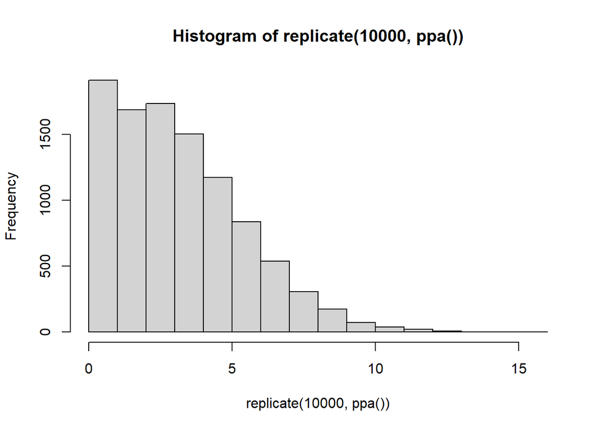

```r
ppa <- function( alpha=1, beta=1, z=3, N=20) {

  posterior <- rbeta(1, z+alpha, N-z+beta)

  X <- rbinom(1, N, posterior)
  return(X)
}

replicate(10000, ppa()) |>
  hist()
```

## Question 2

We keep the example conditions from Question 1.

Now we want to make inference about our posterior:

- Provide the *Mean* and *Median* of the posterior distribution
- Provide the 95% Credible Interval (CrI) for the posterior distribution. The lower end of this interval is the point at which 2.5% of the left side of the PDF are located. The upper is the point at which 97.5% of the area under the PDF is located.

There’s two ways to do this – show both:

1. *Sampling:* Sample 1000 $\theta$ values from the posterior $p(\theta|X)$ and compute the *M*, *Mdn* and *CrI*. The CrI is reported like a confidence interval: CrI[lower_number; upper_number]. Median and CrI can be obtained with the `quantile()` function in R.
2. *Analytic solution:* The posterior is a known PDF – compute the *M* from the analytic solution and compute the *Mdn* and *CrI* with the help of R’s `qbeta(p, shape1, shape2)` to find the quantiles of the Beta distribution. The parameter p indicates the probability, or area under the curve of the PDF, from the left side. 2.5% would be 0.025.
3. *Interpret* the credible interval

```r
# Simulation
dat <- rbeta(1000, 4, 18)

## Mean
mean(dat)
```

```
## [1] 0.1818527
```

```r
## Median and CrI
quantile(dat, c(.025, .5, .975))
```

```
##       2.5%        50%      97.5%
## 0.05290821 0.17288087 0.37055492
```

```r
# Analytic solution

## Mean
alpha <- 4
beta <- 18
alpha/(alpha+beta)
```

```
## [1] 0.1818182
```

```r
## Median and CrI
qbeta(c(.025, .5, .975), alpha, beta)
```

```
## [1] 0.05446357 0.17208954 0.36342399
```

The credible interval indicates that 95% of the posterior probability lies in the range of 0.054 and 0.36.

### Question 3

Now, lets assume we observed 5 PD kids and 50 non-PD. This time we have different prior believes

- Prior 1: Beta( 1, 10)
- Prior 2: Beta( 5, 5)
- Prior 3: Beta(10, 1)

Show the effect of the different priors on the posterior by superposing the PDF’s in the same plot.

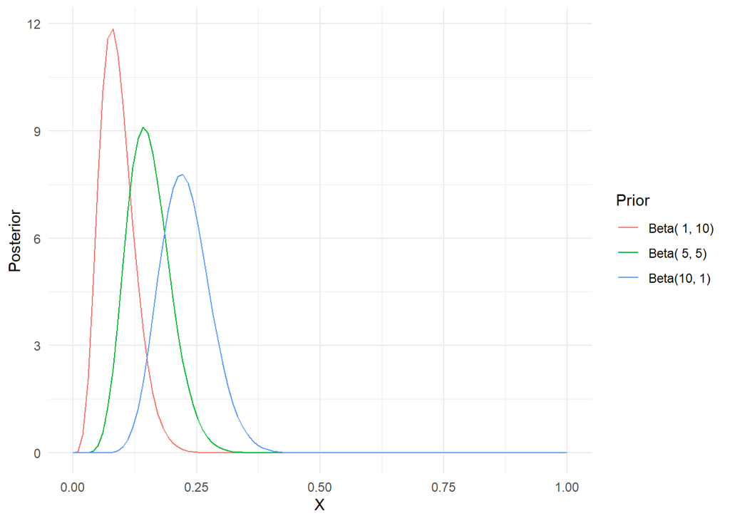

```r
z <- 5
N <- 55
x <- seq (0 ,1 , length.out = 100)

prior_df <- data.frame(
  x = rep(seq (0 ,1 , length.out = 100), by=3),
  Prior = rep(c("Beta( 1, 10)", "Beta( 5, 5)", "Beta(10, 1)"), each=100),
  posterior = c(dbeta(x, z+1, N-z+10), dbeta(x, z+5, N-z+5), dbeta(x, z+10, N-z+1))
)

prior_df |>
  ggplot(aes(x = x, y=posterior, color=Prior)) +
  geom_line() +
  theme_minimal() +
  labs(
    x = "X",
    y = "Posterior"
  )
```

# Conjugate Normal

## Question 4

So far, we have focused on a binomial distribution. Now, let’s assume we measured the intelligence of 30 independent individuals. We think that intelligence is normally distributed and is described by a mean $\mu$ and a variance $\sigma^2$. From previous studies we know that intelligence is consistently hovering around 100. Accordingly, our prior for $\mu$ will have a mean of $\mu_0=100$. Given that we are fairly sure that the population means are close to 100, we chose a small SD of $\sigma_0=10$. With this, we assume that 65% of the population means are somewhere between 90, and 110. Moreover, we *know* that in the population intelligence has a SD of 15. That is, here we assume $\sigma$ to be known.

Note the difference between the mean ($\mu$) and standard deviation ($\sigma$) for the *likelihood* versus the mean ($\mu_0$) and standard deviation ($\sigma_0$) of the *prior*. $\mu_0$ reflects to most likely location of the population mean and $\sigma_0$ described the strength of our believe.

Our model can be written as:

$$\begin{align}
y \sim & N(\mu, \sigma) \quad [\text{Likelihood}] \\
& \mu ~ \sim N(\mu_0 = 100, \sigma_0 = 10) \quad [\text{Prior}]\\
& \sigma = 15 \quad [\text{Known and constant}]
\end{align}$$

Conveniently, we chose a normal prior for $\mu$ and assume $\sigma$ to be known, which means that we can obtain the posterior analytically. Even better, we can look up the posterior for this situation in a table (eg. on [Wikipedia](https://en.wikipedia.org/wiki/Conjugate_prior#When_likelihood_function_is_a_continuous_distribution) ):

$$N\left( \frac{1}{\frac{1}{\sigma_0^2} +
\frac{n}{\sigma^2}} \left(\frac{\mu_0}{\sigma_0^2} + \frac{\sum_{i=1}^n
x_i}{\sigma^2}\right), \left(\frac{1}{\sigma_0^2} +
\frac{n}{\sigma^2}\right)^{-1} \right)$$

Now we obtain 30 independent measurements. We’ll use `set.seed(433)` so that we all have the same data: X = 121, 130, 137, 123, 127, 124, 133, 119, 120, 126, 129, 128, 133, 130, 138, 131, 125, 141, 140, 141, 133, 124, 134, 128, 124, 128, 133, 130, 122, 124.

Compute the posterior, assuming known variance and plot the posterior. Add lines to indicate the lower and upper CrI.

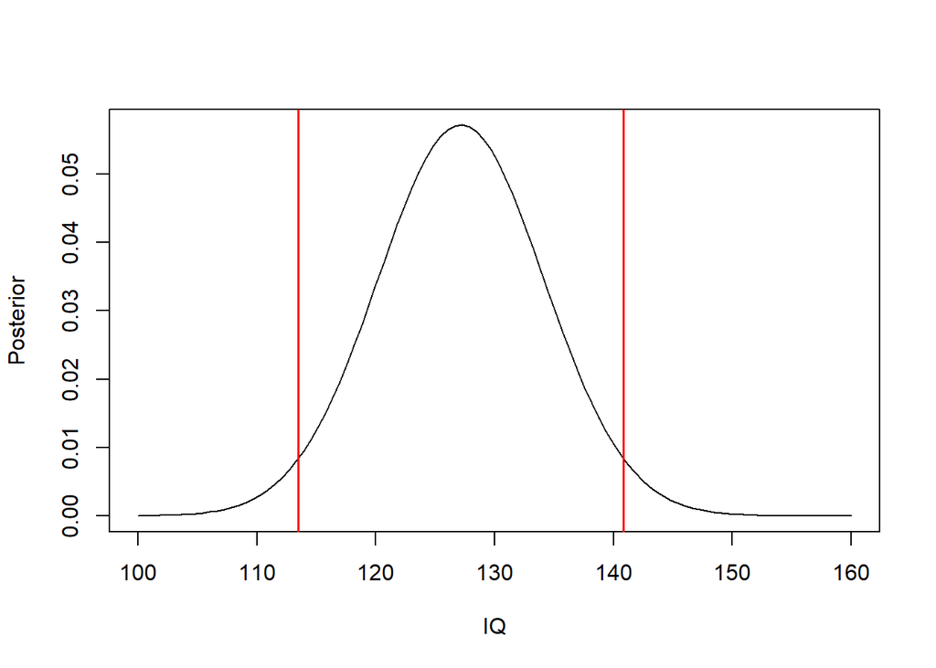

```r
## Observed data are generated as follows:
set.seed(433)
x <- rbinom(30, 200, .65)
set.seed(NULL )

## your code:
n <- 30
sigma_zero <- 10
sigma <- 15
mu_zero <- 100
location <- (1/ ( (1/sigma_zero^2) + (n/sigma^2))) * ( (mu_zero/sigma_zero^2) + (sum(x)/sigma^2))
scale <- ((1/sigma_zero^2) + (n/sigma^2))^(-1)

y <- dnorm(seq(100, 160, length.out =100),  location, scale)
plot(seq(100, 160, length.out =100), y,
     type='l', xlab = "IQ", ylab = "Posterior")

abline(v=qnorm(.025,  location, scale), col="red", lwd=1.5)
abline(v=qnorm(.975,  location, scale), col="red", lwd=1.5)
```

Generate samples from the posterior predictive distribution and compare them to the observed values visually. That is, find a way to juxtapose the observations with the sampled data

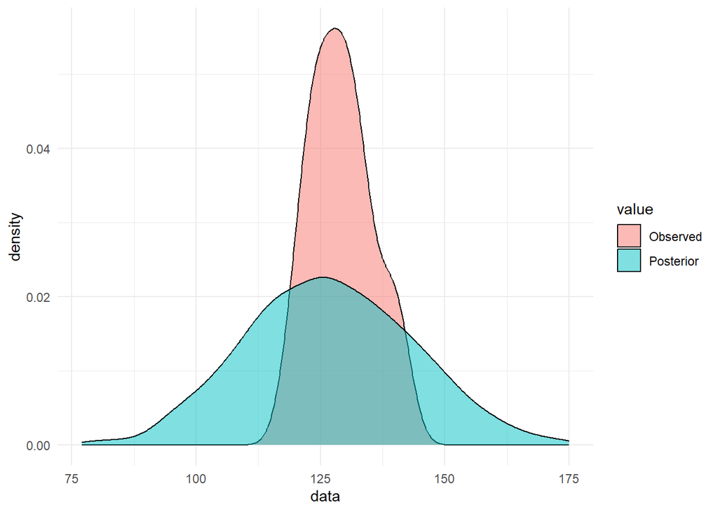

```r
pp_normal <- function( mean, sd) {

  posterior_mean <- rnorm(1, mean, sd)
  iq <- rnorm(1, posterior_mean, 15)
  return(iq)
}

sampled_data <- replicate(1000, pp_normal(mean=location, sd=scale))

data.frame(
  data = c(x, sampled_data),
  value = rep(c("Observed", "Posterior"),c(30, 1000))
) |>
  ggplot(aes(x =data, fill = value )) +
  geom_density(alpha=.5) +
  theme_minimal()
```

Still here? Great! Now compute the 90% predictive interval (90% interval from the posterior predictive distribution) and compare it to the CrI from the posterior:

```r
# 90% predictive interval
quantile(sampled_data, c(.05, .95))
```

```
##        5%       95%
##  99.15584 154.99239
```

```r
# 90% CrI
qnorm(c(.05, .95), location, scale)
```

```
## [1] 115.6871 138.6385
```